# Lab 1

Gregory Backus

3/19/2020

# 1.1 R: A biologist’s one-stop shop for all of their numerical needs!

If you haven’t had the chance already, please download and install both R and RStudio.

R is a free statistical software and a programming language, commonly used for statistics, data analysis, and modeling. Most biologists today seem to be well-versed in R, so you should learn how to use it too! Even if you do plan on studying ecological models or working with lots of data, it is a very free and accessible way to run basic statistics. This isn’t a programming class, this isn’t a statistics class, and it isn’t a class about learning R. So, we will only cover the basics here. It’s more important that you know how to run the code, edit the code, and interpret the results.

*When installing R, just use choose the default options.*

#### Download R: https://ftp.osuosl.org/pub/cran/

Base R could probably run most of the code we’ll be using in lab, but it’s also a little clunky and hard to use. Instead, we’ll use RStudio. This program is also free. It’s much more user-friendly than R, it’s easier to navigate, and it has more options to customize. Really, it’s just R in a pretty costume. But it requires R to work, so make sure you already have R.

*We’ll be using the free open source license for RStudio Desktop. Scroll down until you find the right download for your operating system.*

#### Download RStudio: https://rstudio.com/products/rstudio/download/

# 1.2 Getting used to R

If you haven’t used R or any other programming language before, it might seem strange. There’s a lot to learn, but we’ll only cover the very basics in this class.

Open RStudio. The first time you open it, RStudio will be divided into three boxes. We will ignore the two boxes on the right for now. On the left side of the screen, you’ll see the largest box. This is the “console”. Here, you can run simple commands. Let’s try it!

## 1.2.1 Basic commands

Click into the console. A small vertical black line should be blinking on and off after the “>” symbol. This is where you can type commands for R to run and it will give you back answers. Let’s try this out with simple arithmetic. Type in the following commands and press enter. R should display the result.

#### Addition

*For these examples, I’ll usually include what I input into the R console on top with the answer below.*

```r
1+1
```

```
## [1] 2
```

#### Multiplication

```r
2*4
```

```
## [1] 8
```

#### Exponents

```r
2^4
```

```
## [1] 16
```

#### Parentheses

*Be careful with these. RStudio automatically adds a close-parentheses if you type an open-parentheses. What makes the last two different? If you don’t know, you might need to go back and review some of your prerequisites at this point. If any of the math you encounter today is confusing, please consider reviewing your prerequisites!*

```r
16-12/4
```

```
## [1] 13
```

```r
(16-12)/4
```

```
## [1] 1
```

We can do more complicated math as well. Let’s try. Type the commands and press enter!

*R can be fun. Really!*

#### Logarithms

*The default logarithm function in R is the natural logarithm (base e) and not the base-10 logarithm. You might be more used to seeing the natural logarithm as “ln(x)” (instead of “log(x)” which is often the base-10 logarithm).*

```r
log(50)
```

```
## [1] 3.912023
```

#### The exponential function (e)

*By exponential function, I mean* $e^x$, *where* $e=2.71828...$ *is the base of the natural logarithm. Remember that “e” and “log” (where log is the natural logarithm) tend to cancel each other out, such that* $log(e^x)=x=e^{log(x)}$.

```r
exp(3.912023)
```

```
## [1] 50
```

```r
exp(log(50))
```

```
## [1] 50
```

#### Trigonomety

*If you remember trigonometry, you probably know that* $sin(2\pi)=0$. *What’s going on in our answer here? Why isn’t that 0? Well, `-2.449213e-16` is in scientific notation and `e` in this case means* $10^x$. *That means the answer is `-0.0000000000000002449213`. This is very, very, very close to 0 (but not quite)! Computers can be inexact, and this sometimes leads to problems, but for most purposes, we can treat this as 0.*

```r
sin(2*pi)
```

```
## [1] -2.449213e-16
```

## 1.2.2 Variables

We usually don’t work with numbers directly. Instead, we might assign a value to a variable. This allows us to use that variable name instead of its value. To do this we choose a variable name and assign a value to that name with `<-`. For example, as I’m writing this, it will be 53 degrees Fahrenheit today. As a scientist, I want to know what that temperature is in Celsius. Type the following example into the console to find this in R.

*Note that the definition of “variable” is different depending on whether you’re talking about programming, math, or statistics. Unfortunately, we might talk about all of them in this course. When programming, a variable is typically a name and its associated value(s). Sometimes a “variable” can be a number, a vector, or even an actual word (usually called a “string”). Don’t worry too much about this, as it should usually be clear from context.*

```r
tempF <- 53
(tempF-32)*5/9
```

```
## [1] 11.66667
```

*I usually leave a space on either side of `<-` to make the code easier to read. R should understand the code either way, regardless of whether there is a space or not.*

You could assign the answer to a variable as well. However, if you want to see the result, you’d have to type in that variable name and press enter.

```r
tempC <- (tempF-32)*5/9
tempC
```

```
## [1] 11.66667
```

*Tip: Make sure you give everything a clear name. If you’re writing a long program, it would be confusing if all of your variables were named “a”, “b”, “c”, and “d” instead of something informative like “tempC”, “squirrelDens”, “birthRate”, and “mortality”.*

Why are we going through this trouble of naming our numbers? It’ll make it easier to calculate things later if we need to change a value.

#### General tips: Spacing

When you’re typing out your code, it doesn’t matter how many spaces you have between “words” but it does matter within “words”.

For example, compare

```r
(tempF-32)*5/9
```

```
## [1] 11.66667
```

with

```r
( tempF - 32 ) * 5 / 9
```

```
## [1] 11.66667
```

and

```r
(tem pF-32) * 5/9
```

```
## Error: <text>:1:6: unexpected symbol
## 1: (tem pF
##          ^
```

It’s often convenient to include these spaces to help organize your code, but be careful you don’t change the meaning!

```r
tempC <- (tempF-32)*5/9
```

might look nicer than

```r
tempC<-(tempF-32)*5/9
```

but you don’t want to separate the `<` and the `-`, or you’ll get something a little different!

```r
tempC < - (tempF - 32)*5/9
```

```
## [1] FALSE
```

#### General tips: Capitalization

Capitalization is important! Look at the difference between

```r
tempC
```

```
## [1] 11.66667
```

and

```r
tempc
```

```
## Error in eval(expr, envir, enclos): object 'tempc' not found
```

or

```r
TempC
```

```
## Error in eval(expr, envir, enclos): object 'TempC' not found
```

#### General tips: Save some time

R saves you history in the console. If you’ve already entered a command and want to run it again, click into the console and press the up arrow. Notice that the last thing you entered is there! Press up and down to find whatever commands you want. Scroll up to `sin(2*pi)` and press enter.

## 1.2.4 Example: Growing some worms at home

Stuck in isolation and unable to see my friends, I decided to grow some of my own. I want to grow some newly discovered nematodes (roundworms) found at the ARC called *Ucalifornia aggii*. *(Don’t worry, this doesn’t actually exist.)* This species has a very short lifespan, with one day between birth, reproduction, and death. They reproduce each day in the afternoon (when the temperature is at its maximum for the day), and the number of offspring they produce depends on the temperature at the time.

I placed a(n infinitely large) jar with 100 *U. agii* worms outside on my back porch. Wanting to know how long it will take to have more nematode friends, I decide to model their growth. A colleague of mine who studied these species in the lab tells me that *U. agii* have an optimal growth rate at `tempCOpt <- 16` degrees Celsius and a thermal tolerance of `tempCToler <- 3` degrees Celsisus. Altogether, the daily discrete-time growth rate is

$R= 2 \exp\left(-\left(\frac{tempC-tempCOpt}{tempCToler}\right)^2\right),$

where $tempC$ is the temperature at the time when the species reproduces its next generation.

*Sorry if this notation is confusing. Discrete-time growth rates are usually called* $R$ *but that’s also the name of the programming language that we’re using. Hopefully, you can figure it out from context.*

Now let’s calculate (the discrete-time growth rate of nematodes) $R$ on my patio in R(Studio)!

*Remember that we already calculated `tempC` before. RStudio should remember this, unless you redefined the variable, deleted the variable, or closed the program since then. I don’t see why you would have done that.*

First, we should assign values to `tempCOpt` and `tempCToler`. Enter these into the console.

```r
tempCOpt <- 16
tempCToler <- 3
```

Now we type in the equation for `R` and look at the discrete-time growth rate. Enter these into your console.

```r
R <- 2*exp(-((tempC-tempCOpt)/tempCToler)^2)
R
```

```
## [1] 0.2482615
```

## Questions

### On a separate Word or text document, answer the following based on what you learned in class and what you’ve learned so far in lab today. Save this file as “lab1yourkerberosid.doc” or “lab1yourkerberosid.txt”. Make sure you copy/paste the questions and answer the questions in full sentences when possible!

#### **1.a Given what you know about discrete-time exponential growth, are the *U. agii* growing or declining today at 53$^\circ$F? Why or why not?**

#### **1.b What is the temperature where you are today in Fahrenheit? Now, let’s make use what we learned about variables. Change the value of `tempF` to todays temperature in Fahrenheit. Run the rest of the commands we did before. Would the nematodes grow today if you put the jar outside your window with 100 nematodes in it? How many nematodes will be there tomorrow? Explain your reasoning.**

*Note that `tempC` is not automatically updated when you redefine `tempF`. You’ll need to rerun the line where we calculate `tempC`. Remember, you can press the up button inside the console to go back to a previous line that you’ve entered.*

# 1.3 Getting more advanced

## 1.3.1 Vectors

We can also use vectors in R. In the next week, the weather forecast says the temperature in the coming week will be 53$^\circ$F today, 61$^\circ$F tomorrow, and then 65$^\circ$F, 69$^\circ$F, 62$^\circ$F, 57$^\circ$F, 57$^\circ$F. Let’s put this in a vector. Type in the following.

```r
tempFWeek <- c(53,61,65,69,62,57,57)
```

The function `c()` creates a vector. c() is short for “concatenate” or “combine”. Everything inside the parentheses is in the vector. The comma separates entries in the vector.

Want to know what the temperature in Celsius will be in the next week? We can do the same thing we did with the single value since R can do this calculation on an entire vector at once! Try this.

```r
tempCWeek <- (tempFWeek-32)*5/9
tempCWeek
```

```
## [1] 11.66667 16.11111 18.33333 20.55556 16.66667 13.88889 13.88889
```

We can also ask R for a single entry in the vector with square brackets. Try

```r
tempCWeek[1]
```

```
## [1] 11.66667
```

to find the temperature in Celsius today and

```r
tempCWeek[5]
```

```
## [1] 16.66667
```

to find the temperature in Celsius four days from now. If we want to see multiple entries at the same time, we can even do something like

```r
tempCWeek[c(1,2,3)]
```

```
## [1] 11.66667 16.11111 18.33333
```

## 1.3.2 Script files

By now, you’re probably tired of typing everything out and pressing enter over and over. Now we’re ready to write our own code that we can run as many times as we want to! With a script file, you can write out all of the code and run it later.

Let’s try it. Click on “File” in the top-left corner. Then go to “New File” and then “R Script”.

A blank white box should pop up in the top-left corner of RStudio. It’ll squeeze the console downward. This is our script file which will put all of the code that we want to run.

Now let’s put together a some code. Click into the new box in the top-left corner.

Type or copy-paste the following to see how the *U. agii* will grow over the next week if I leave it on my back porch.

*R might have trouble with copy-pasting multiple lines. Make sure that each line in the code below is on a separate line in your script file. Each command (like defining a new variable) needs to be on a separate line to run properly.*

*Also, spaces between lines do not matter in R. You can press “enter” between lines as many times are you want and the code will run the same. I often leave extra spaces so the code is easier to read.*

```r
tempFWeek <- c(53,61,65,69,62,57,57)
tempCWeek <- (tempFWeek-32)*5/9

tempCOpt <- 16
tempCToler <- 4

RWeek <- 2*exp(-((tempCWeek-tempCOpt)/tempCToler)^2)
```

At the top of the script box, you will see a tab that says “Untitled1”. That’s the name of your file. You should save it now. Under that tab with “Untitled1”, you should see a series of symbols. The fourth one looks like an old floppy disk (or if you don’t know what that is, it is a blue square with two rectangles inside). Find a folder on your computer where you want to save your lab files and name this file “lab1Examples.R”.

Now that we’ve written out that code, let’s run the code. All the way to the right of the floppy disk, you should see a button that says “Source” on it. Click that.

See if the code ran properly. Click back into the console on the bottom-left. Type in `RWeek` to see the disrete-time growth rate for every day of the week. Like this

```r
RWeek
```

```
## [1] 0.6184964 1.9984574 1.4231453 0.5466641 1.9452090 1.5137618 1.5137618
```

Suppose I want to know how well *U. aggii* are going to grow in LA. The weather there is going to be `c(60,64,66,65,63,62,61)` degrees Fahrenheit over the next week. Go back to the script file and change the value of `tempFWeek` to the temperature in LA. Now click “Source” again to run the code. Did the value of `RWeek` change?

Change back to `tempFWeek <- c(53,61,65,69,62,57,57)` afterwards.

## 1.3.3 Functions

We can make this calculation even easier with something called a “user-defined function”. Previously, you’ve used some of R’s pre-defined functions. For example, `log()` takes the natural logarithm of the values you put inside the parentheses and `sin()` takes the sine of what you put inside the parentheses.

It can be useful to make our own if there’s something we want to calculate often. For example, if we want to find the squared value of a number often, we could make a function called `square()` like this:

*Don’t worry about putting this `square()` function into R yourself. This is just an example that you don’t need to do.*

```r
square <- function(n){
  nSquared <- n^2
  return(nSquared)
}
```

Here, `square` is the name of the function, `n` is the value we input, everything inside the curly brackets tell the function what to do, and everything inside of `return()` tells the function what to output.

We can test this to see if it works

```r
square(2)
```

```
## [1] 4
```

```r
square(4)
```

```
## [1] 16
```

```r
square(square(2))
```

```
## [1] 16
```

We’ve already converted degrees Fahrenheit to degrees Celsius several times in this lab. Let’s just define that as a function so we can stop writing it out.

Just as we assigned a name to value, we need to assign a name to a function. We’re going to call this one `farhToCels`.

We tell R that we’re making a new function with the function `function()`. Everything within the parentheses should be what we want as our input into the function. For this function, we’ll want our input to be temperature in degrees Fahrenheit (or `tempF`).

Then, everything that we want the function to do will follow and be included inside a curly brackets.

Then, we use `return()` to tell the function what to output.

This gives us:

```r
fahrToCels <- function(tempF){
  tempC <- (tempF-32)*5/9
  return(tempC)
}
```

Add this function definition to the end of your script file.

*If you’re copy-pasting, make sure everything is on a separate line! Either way, I’d recommend typing this into your script file to help you learn how R works.*

Also, we can do this for converting degrees Celsius to discrete-time growth rate. We can allow multiple inputs this time in case we want to change `tempCOpt` and `tempCToler` as well (maybe we find a nematode that prefers cooler temperatures and is more tolerant of a wider range of temperatures). Just separate input inside `function()` with a comma.

```r
celsToGrowthRate <- function(tempC,tempCOpt,tempCToler){
  growthRate <- 2*exp(-((tempC-tempCOpt)/tempCToler)^2)
  return(growthRate)
}
```

Add this to the end of your script file as well. To make these functions available in R, press the “Source” button again to run the file.

Now see if the functions work. Try them out with conversions you probably already know. Enter these into your console to test out the new functions.

```r
fahrToCels(32)
```

```
## [1] 0
```

```r
fahrToCels(212)
```

```
## [1] 100
```

```r
fahrToCels(tempFWeek)
```

```
## [1] 11.66667 16.11111 18.33333 20.55556 16.66667 13.88889 13.88889
```

See how they works with with single numbers and vectors? Now try out the `celsToGrowthRate()` function.

```r
celsToGrowthRate(tempC,tempCOpt,tempCToler)
```

```
## [1] 0.6184964
```

```r
celsToGrowthRate(tempCWeek,tempCOpt,tempCToler)
```

```
## [1] 0.6184964 1.9984574 1.4231453 0.5466641 1.9452090 1.5137618 1.5137618
```

Also, you can use different values for the thermal optimum and thermal tolerance by entering different values into the function. (You don’t need to redefine `tempCOpt` and `tempCToler` to do this.)

```r
celsToGrowthRate(12,12,5)
```

```
## [1] 2
```

We can even combine these function into another function. Add this to the end of your script file and press “Source”.

```r
fahrToGrowthRate <- function(tempF,tempCOpt,tempCToler){
  tempC <- fahrToCels(tempF)
  R <- celsToGrowthRate(tempC,tempCOpt,tempCToler)
  return(R)
}
```

Now we can use this function to see how well nematodes grow in different temperatures. Try using the `fahrToGrowthRate()` function in your console with the temperature in your room and the temperature outside. In which one would the *U. aggii* grow better?

## 1.3.4 Plotting

Especially if we have many numbers to look at, it can be easier to look at our results graphically. Let’s learn how to use the `plot()` function.

Perhaps we want to know which temperatures are best for *U. aggii*. We can plot the growth rate over a range of different temperatures.

First let’s make a vector for range of temperatures from 0 to 30 Celsius. You *could* enter this into your console.

```r
tempCRange <- c(0,1,2,3,4,5,6,7,8,9,10,11,12,13,14,15,16,17,18,19,20,22,22,23,24,25,26,27,28,29,30)
```

Wow! That’s a lot of work to type that out.

*Also, notice that I made a mistake there. That happens a lot when you’re coding. Be careful to check over your code for mistakes. Sometimes a mistake means that your code won’t work at all. That can be frustrating. However, sometimes (like above), you make a mistake and your code will still work. That’s more dangerous, because that mistake will continue throughout the rest of your code! You’ll have the wrong results later!*

Thankfully, there are much easier ways to get a range. Here are two other options.

```r
tempCRange <- 0:30
tempCRange <- seq(0,30)
```

See how these are much easier to type out and much harder to make mistakes? Take one of these `tempCRange` assignments and put it into the end of your script file.

Now let’s use `tempCRange` and the `celsToGrowthRate()` function to find the discrete-time growth rate of *U. aggii* over that range of temperatures and assign the output as `RRangeC`. Put that as the next line in your script file and run your code by pressing the “Source” button.

*I am not telling you how to do this one because I believe that you should be able to do it at this point. If not, please ask for help!*

*Also, remember that `tempCOpt` and `tempCToler` should already be previously defined in your code.*

Now to look at a plot, try typing in `plot(tempCRange,RRangeC)`. The first input before the comma is what goes onto the x-axis and the second input is what goes on the y-axis. Because we’re trying to see how temperature affects growth rate, we want temperature on the x-axis and growth rate on the y-axis. Also, keep in mind that we usually want the first vector to be the same length as the second vector. Let’s see what it looks like. Type the following into your console and press enter.

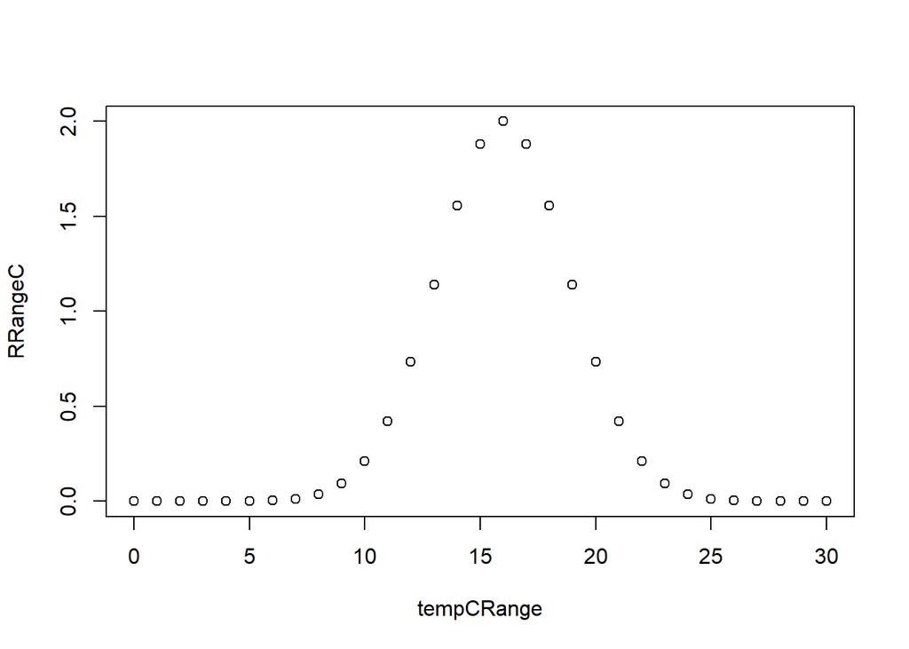

```r
plot(tempCRange,RRangeC)
```

In the bottom-right box, you should notice a plot appear! However, it is better to look at this type of data with a line graph. To do this we add an optional `type='l'` (that’s a lowercase “L” for line, not the number “1” or the capital “i”) at the end of our `plot()` function, separated by a comma. It should look like this. Put this into your script file and run your code.

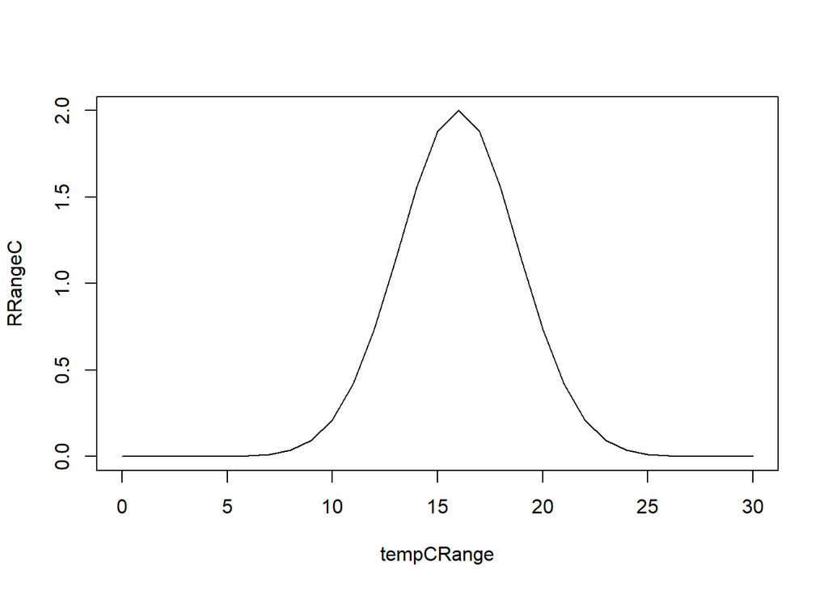

```r
plot(tempCRange,RRangeC,type='l')
```

The `plot()` function has a whole bunch of other options as well. If you want to learn more about them, try typing `?plot` into your console. You’ll notive that the bottom-right box in RStudio will turn into a help file that explains the function in more detail. If you ever have questions about any other pre-built functions, just check them out with `?`. (For example, try `?log` or `?seq`).

What if you want to add another line to compare? We can do this with the `lines()` function.

Let’s try it out with an example. Suppose we have another nematode called *U. goldenbeari* with a thermal optimum of 13$^\circ$C and a temperature tolerance of 5$^\circ$C.

Add some code to your script file above the `plot` line to find this. Add a line to find the growth rate of *U. goldenbeari* under temperatures `tempCRange` using `celsToGrowthRate()` function, `tempCRange`, and new values for `tempCOpt`, and `tempCToler`. Name the new growth-rate vector `RRangeC2`.

Now after the `plot` line, add `lines(tempCRange,RRangeC2,col='red')`. The `col='red'` argument makes the line color red so we won’t confuse it with *U. aggii*.

Afterward, the last two lines of your code should look like this and the plot in the bottom-right should look like this.

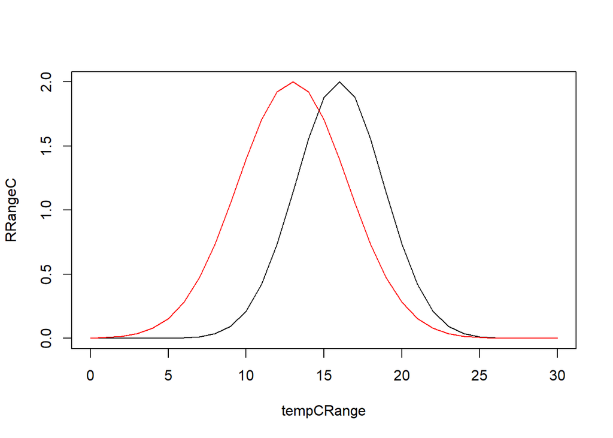

```r
plot(tempCRange,RRangeC,type='l')
lines(tempCRange,RRangeC2,col='red')
```

It’s good practice to rename your axes to something clear and useful. Who knows what `tempCRange` or `RRangeC` are? We can do this by adding more options to the `plot()` function. After `type='l'`, we should add an `xlab` and a `ylab`.

*We don’t need to change anything for the `lines()` function, because it is just added onto the `plot()` that was already defined.*

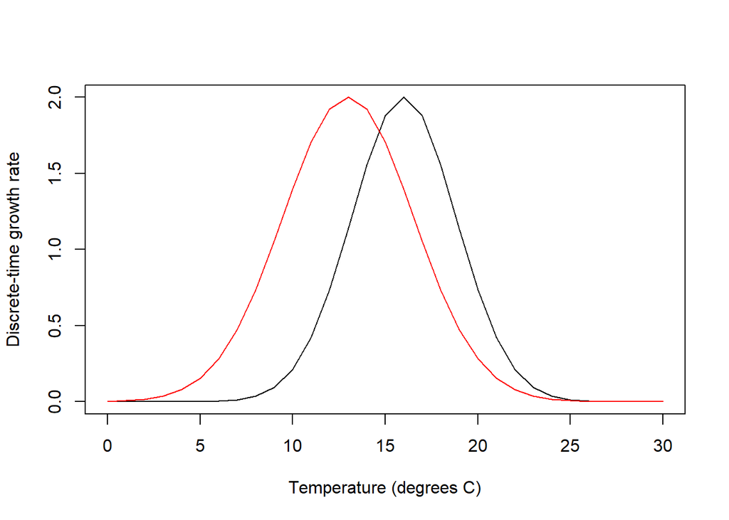

```r
plot(tempCRange,RRangeC,type='l',xlab="Temperature (degrees C)",ylab="Discrete-time growth rate")
lines(tempCRange,RRangeC2,col='red')
```

*R automatically sets the y-axis limits based on the first plot. When plotting multiple lines on the same plot, you might need to change the axis limits. To do this, add another argument to the plot function `ylim=c(min,max)`, where `min` and `max` are the minimum and maximum values you want to see. If you want to try it on the last plot, change it to `plot(tempCRange,RRangeXC,type='l',ylim=c(-1,3))`.*

## Questions

### Answer these questions in your Word/text document “lab1yourkerberosid.doc” or “lab1yourkerberosid.txt”.

#### **2.a Roughly, in what range of temperatures (in degrees Celsius) would you expect *U. aggii* to grow? In what range of temperatures would you expect *U. goldenbeari* to grow? How do you know?**

#### **2.b Roughly, in what range of temperatures (in degrees Fahrenheit) would you expect *U. aggii* to grow? Include the function you used to find this.**

*To find this, add some code to the end the script file to define a range of temperatures in degrees Fahrenheit from 32 to 86 and name this vector `tempFRange`. Add another line to find the growth rate at these temperatures with the `fahrToGrowthRate()` function and name this vector `RRangeF`. Add one more line to plot this.*

#### **2.c Double-check you last answer by adding a new function to your script file called `celsToFahr()`. The conversion from Celsius to Fahrenheit is `tempC*9/5+32`. Did they roughly match? Include the function you used to find this.**

#### **2.d Let’s try a different species of nematode called *U. bruini* with `tempCOpt <- 24` $^\circ$C and `tempCToler <- 4.5` $^\circ$C. Which nematode would grow better on your patio today where you live? Why or why not?***

*To find this, add a line to find the growth rate of this species under temperatures `tempCRange` using `celsToGrowthRate()` function, `tempCRange`, and new values for `tempCOpt`, and `tempCToler`. Name the new growth-rate vector `RRangeC3`. Add one more line to plot this.*

# 1.4 Loops

When programming, it is often convenient to repeat something over and over again. We can do this with loops!

Suppose we want to add 1 together 10 times. *(I don’t know why we’d want to do that, but it’s an easy example.)*

First we need to set up the variable we’re adding together. We’ll call it `a`. This is typically called “pre-allocating”.

Next, we have to make our for-loop. *(We’re only going to consider for-loops in this class, but know that there are other kinds as well.)* We use this when we want to repeat action **for** a certain number of times.

If we want to do something 10 times, we’d typically start our for-loop with `for(i in 1:10)`. This means that it’ll repeat for every number between 1 and 10. *(Don’t worry about the `i` for now. We’ll get to that soon.)*

Then we put everything we want to repeat inside of curly brackets. In this case, we want to repeat the process of adding 1 to `a`. In the process, we’re going to redefine `a` to be `a+1` each time we go through the loop. In other words we repeat `a <- a+1` for 10 times.

Let’s look at it. *You don’t need to do this one. It’s just an example.*

```r
a <- 0
for(i in 1:10){
  a <- a+1
}
a
```

```
## [1] 10
```

Now what if we want to do something slightly different each time we go through the loop? Instead of adding `1`, we could add progressively larger numbers. Remember the `i` from the beginning of the for-loop? That value `i` is redefined each time it goes through the for-loop. When we have `for(i in 1:10)`, then `i` starts out as `1` for the first time through the loop, then `i` is `2` for the second time through the loop, and so on until we get to `10`.

Let’s test this out by adding up all of the numbers from 1 to 10.

```r
a <- 0
for(i in 1:10){
  a <- a+i
}
a
```

```
## [1] 55
```

Let’s see if that worked.

```r
1+2+3+4+5+6+7+8+9+10
```

```
## [1] 55
```

Great!

Let’s bring this back to population growth! Recall that change in population via exponential growth in discrete time can be defined as

$N_{t+1} = RN_t$.

Then if we start with an initial population size of $N_0=100$ and a growth rate of $R=1.2$, we can use a for-loop to see what the population will look like at $t=10$.

```r
N <- 100
R <- 1.2
for(i in 1:10){
  N <- N*R
}
N
```

```
## [1] 619.1736
```

Recall that the population at any year $t$ could be calculated from the growth rate $R$ and the initial population size $N_0$ with the equation

$N_t=R^tN_0$.

We can check to see if we get the same answer

```r
N <- 100
R <- 1.2

N*R^10
```

```
## [1] 619.1736
```

We might be interested in how the population changes over 10 time steps instead of just the final population size at time $t=10$. To keep track of the population over time, we can save the results in a vector.

First, we need to pre-allocate a vector `Nt`. Pre-allocating is a bit trickier here since we need to define the entire vector beforehand! We’ll want to make `Nt` a vector of length 11 (*10 time steps plus 1 for the initial population size*). However, since we don’t know what most of these population sizes are going to be, they are merely placeholders that are going to be redefined later. Our placeholders will just be equal to `0` for now.

We can do with help from the `rep(x,y)` function. This just creates a vector that repeats `x` a total of `y` times. Therefore, our pre-allocated vector is going to be `Nt <- rep(0,11)`.

Next we need to change the first entry of the vector to be the initial population size `Nt[1] <- 100`.

*Remember that we can ask R for any entry within a vector using the square brackets and the number of the entry you want. For example `Nt[5]` is the fifth number in the vector `Nt`. We can redefine entries that way too! Like this `Nt[5]<-101’.*

Then, as we go through the for-loop from `i=1` to `i=10`, we can caclulate the value of the popualtion size at the next time step (`Nt[i+1]`) as the population size of current time step (`Nt[i]`) times the growth rate (`R`).

```r
Nt <- rep(0,11)
Nt[1] <- 100
R <- 1.2
for(i in 1:10){
  Nt[i+1] <- Nt[i]*R
}
Nt
```

```
##  [1] 100.0000 120.0000 144.0000 172.8000 207.3600 248.8320 298.5984 358.3181
##  [9] 429.9817 515.9780 619.1736
```

There is another way to model this (and there are almost always several ways to model a problem)!

Suppose we want to make our for-loop based on the equation $N_t=R^tN_0$. Then we could code this into a loop instead:

```r
Nt <- rep(0,11)
Nt[1] <- 100
R <- 1.2
for(i in 1:10){
  Nt[i+1] <- Nt[1]*R^i
}
Nt
```

```
##  [1] 100.0000 120.0000 144.0000 172.8000 207.3600 248.8320 298.5984 358.3181
##  [9] 429.9817 515.9780 619.1736
```

Remember that we can plot these too! Here’s how the population changes from time 0 to 10.

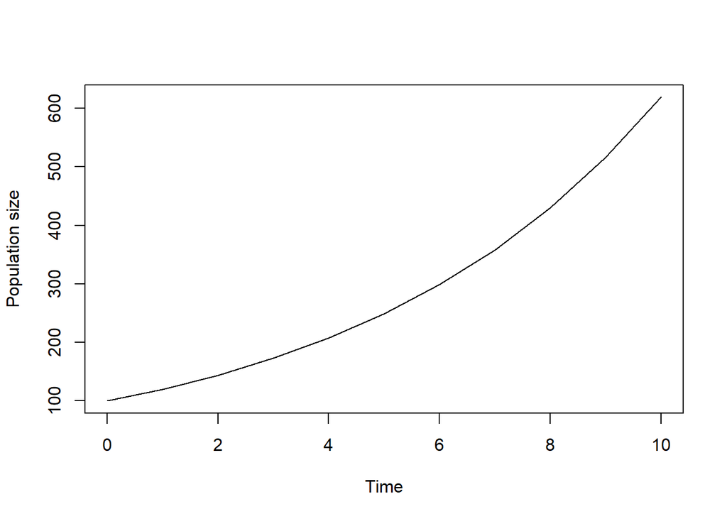

```r
plot(0:10,Nt,type='l',xlab="Time",ylab="Population size")
```

# 1.4 Putting it all together

Let’s simulate how the nematode population will change over the next week.

Recall that change in population via exponential growth in discrete time can be defined as

$N_{t+1} = RN_t$.

Using this equation, we found that the population at time $t$ could be calculated if we knew the growth rate $R$ and the initial population size $N_0$. That is,

$N_t=R^tN_0$.

This is a good place to start, but our nematode is a little different, since its growth rate depends on temperature. In other words, $R$ is not a constant, but a function that depends on temperature. For our nematode, $R$ changes with every time step. Instead, let’s call the growth rate $R_t$ to specify that the growth rate changes with time $t$. Going back to our discrete-time exponential growth equations, we have

$N_{t+1} = R_tN_t$.

Similar to what we saw in page 14 of Alan Hastings’ *Population Biology*, we can expand this outward,

$N_3 = R_2N_2 = R_2(R_1N_1) = R_2(R_1(R_0N_0))$.

This isn’t as clean and convenient as before, but we ultimately end up with

$N_t = (R_{t-1}\cdot R_{t-2}\cdot...\cdot R_0)N_0 = N_0\displaystyle\prod_{i=0}^{t-1}R_i$.

*Note: If you haven’t seen the* $\displaystyle\prod_{i=0}^{t-1}R_i$ *notation before, then you should know that* $\prod$ *is the product symbol.* *Just think of* $\prod$ *as the multiplication version of the summation symbol* $\sum$. *It means that we’re multiplying together each combination of* $R_i$ *from* $i=0$ *to* $i=t-1$.

Therefore, if we want to know the population size at time $t$, all we need to know is the initial population size $N_0$ and a vector of discrete-time growth rates from time $0$ to time $t-1$.

## 1.4.1 Excercise

Let’s use this to simulate how 4 different nematode populations change over time! Please submit this code

### This exercise should be submitted as a separate “.R” file in addition to your Word/text document.

#### A. Open a new script file and save it as “lab1yourkerberosid.R”.

#### B. Begin this file by defining the `celsToGrowthRate()` function.

#### C. Now create a vector for the temperatures in Celsius where you are in the coming week. Call this vector `tempHere’.

#### D. Find the growth rates for the following species over the next week. Differentiate between these by giving them all clear names like `RUaggii’, ‘RUgoldenbeari’, ‘RUbruini’, and ‘RChorneti’.

[output not shown]

#### F. Make a vector to keep track of the population size of each species. They should all start with a population size of 100. Differentiate between these populations by giving them all clear names like `NUaggii’, ‘NUgoldenbeari’, ‘NUbruini’, and ‘NChorneti’.

#### G. Use a for-loop (or series of for-loops) to find how these four species change in population size over time.

#### H. Plot all four of these against each other on a single plot with the `plot` and `lines` functions. To make it clear which is which, make the line for *U. aggii* blue, *U. goldenbeari* cyan, *U. bruini* black, and *C. horneti* red.

*Don’t forget that you probably need to change the y-axis limits when viewing the plots. I’d suggest including `ylim=c(0,max(NUaggii,NUgoldenbeari,NUbruini,NChorneti)` at the end of your `plot()` function*.

*Also, don’t forget to label your axes with `xlab` and `ylab`!*

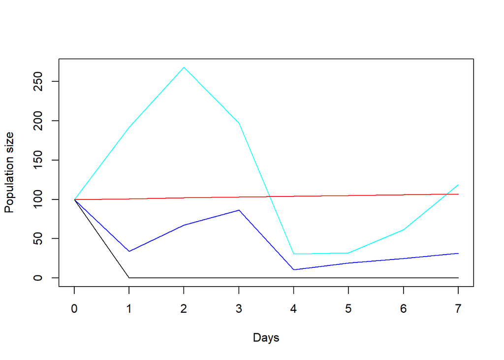

*Your result should look something like this.*

## Questions

### Answer these questions in your Word/text document “lab1yourkerberosid.doc” or “lab1yourkerberosid.txt”.

#### **3.a Breifly describe what happens to each species. Is one species always doing better than the others? Which species is the largest at the end of the week? Do any of them go extinct?**

#### **3.b Plot the temperature over the course of the week. Based on what you know about each species, do the population changes make sense?**

#### **3.c Determine the species that has the highest population and the species that has the lowest population at the end of the week. Change the initial population sizes of each species. Can you change the initial population sizes so that the previously lowest population has the highest population at the end of the week? Can you change the initial populations sizes so that the previously highest population has the lowest population at the end of the week? How much do you need to change these initial population sizes by to get that result? Base on this, what do you expect is more important in determining long-term population dynamics: initial population size or growth rate? Why?**